# Verify the Claim: New Census figures on Philly neighborhoods show inequality, high numbers of whites living in poverty

Author

Tegan Lochner

Published

September 23, 2026

# Part 1 — Reconstruct the Data

**Variables Used**

B17001_001E : total population for whom poverty status is determined - This will be used to determine the poverty rate. Using “B01003_001E : total population” would not be accurate because the ACS excludes some people from their poverty rate calculation if they are determined inapplicable.

B17001_002E : total population below the poverty level - This will be used to determine the poverty rate. Dividing the total population below the poverty level by the total population applicable will give me the poverty rate.

B17001_001M : MOE for the total - The margin of error will allow me to determine the certainity of the statistical outcome.

B17001_002M : MOE for below poverty - The margin of error will allow me to determine the certainty of the statistical outcome.

I used the 2006-2010 ACS5 survey data to represent the 2010 data mentioned in the article, and the 2013-2017 ACS5 survey data to represent the 2017 data mentioned in the article. Although the article mentions some data from the 2016 ACS1 report, it’s main claim compares the change in the poverty rate from 2010 to 2017. The two periods do not overlap.

I assumed that the article correctly calculated the poverty rate by using “total population for whom poverty status is determined” rather than just “total population”. I myself did not realize that this is the correct way to calculate the poverty rate before reading this on the US Census Bureau website.

# Part 2 — Test (code plus interpretation)

**Data Setup**

```r
library (tidycensus)
library(tidyverse)
library(scales)
library(gt)
```

```r
vars <- c(
total = "B17001_001",
below = "B17001_002"
)

acs_2010 <- get_acs(
  geography = "tract",
  variables = vars,
  state = "PA",
  county = "Philadelphia",
  year = 2010,
  survey = "acs5",
  output ="wide"
)

acs_2017 <- get_acs(
  geography = "tract",
  variables = vars,
  state = "PA",
  county = "Philadelphia",
  year = 2017,
  survey = "acs5",
  output = "wide"
)
```

**Compute the Poverty Rate**

```r
acs_2010 <- mutate(acs_2010, poverty_rt = belowE / totalE)
acs_2017 <- mutate(acs_2017, poverty_rt = belowE / totalE)
```

**Compute the Margin of Error (MOE)**

```r
acs_2010 <- mutate(acs_2010, poverty_moe = moe_prop(
  belowE,
  totalE,
  belowM,
  totalM
))

acs_2017 <- mutate(acs_2017, poverty_moe = moe_prop(
  belowE,
  totalE,
  belowM,
  totalM
))
```

**Compute the coefficient of variation**

```r
acs_2010 <- mutate(acs_2010, poverty_cv = ((poverty_moe / 1.645) / poverty_rt) * 100)
acs_2017 <- mutate(acs_2017, poverty_cv = ((poverty_moe / 1.645) / poverty_rt) * 100)
```

**Flag reliability using the Jurjevich et al. (2018) thresholds: CV < 12% reliable, 12–40% somewhat reliable, > 40% unreliable.**

```r
reliability_table_2010 <- acs_2010 |>
  mutate(
    dot = case_when(
      is.na(poverty_cv) ~ "",
      poverty_cv < 12 ~ "🟢",
      poverty_cv <= 40 ~ "🟡",
      TRUE ~ "🔴"
    ),
    flag = case_when(
      is.na(poverty_cv) ~ "Not available",
      poverty_cv < 12 ~ "Reliable",
      poverty_cv <= 40 ~ "Somewhat reliable",
      TRUE ~ "Unreliable"
    )
  ) |>
  arrange(desc(poverty_cv)) |>
  select(
    dot,
    NAME,
    totalE,
    belowE,
    poverty_rt,
    poverty_moe,
    poverty_cv,
    flag
  )

reliability_table_2010 |>
  gt() |>
  fmt_number(
    columns = c(totalE, belowE),
    decimals = 0
  ) |>
  fmt_number(
    columns = poverty_rt,
    decimals = 1,
    scale_by = 100
  ) |>
  fmt_number(
    columns = poverty_moe,
    decimals = 3
  ) |>
  fmt_number(
    columns = poverty_cv,
    decimals = 1
  ) |>
  cols_label(
    dot = "",
    NAME = "Census Tract",
    totalE = "Population",
    belowE = "Below Poverty",
    poverty_rt = "Poverty Rate (%)",
    poverty_moe = "MOE",
    poverty_cv = "CV (%)",
    flag = "Reliability"
  ) |>
  cols_align(
    align = "center",
    columns = dot
  ) |>
  tab_header(
    title = "Reliability of Philadelphia Census Tract Poverty Rates",
    subtitle = "ACS 2006–2010 5-year estimates"
  ) |>
  tab_source_note(
    "Reliability thresholds follow Jurjevich et al. (2018): CV < 12% reliable, 12–40% somewhat reliable, > 40% unreliable."
  )
```

Reliability of Philadelphia Census Tract Poverty Rates

ACS 2006–2010 5-year estimates

|  | Census Tract | Population | Below Poverty | Poverty Rate (%) | MOE | CV (%) | Reliability |
| --- | --- | --- | --- | --- | --- | --- | --- |
| 🔴 | Census Tract 231, Philadelphia County, Pennsylvania | 1,090 | 0 | 0.0 | 0.100 | Inf | Unreliable |
| 🔴 | Census Tract 9801, Philadelphia County, Pennsylvania | 67 | 0 | 0.0 | 1.627 | Inf | Unreliable |
| 🔴 | Census Tract 9806, Philadelphia County, Pennsylvania | 92 | 9 | 9.8 | 0.138 | 85.5 | Unreliable |
| 🔴 | Census Tract 235, Philadelphia County, Pennsylvania | 1,022 | 49 | 4.8 | 0.056 | 71.6 | Unreliable |
| 🔴 | Census Tract 236, Philadelphia County, Pennsylvania | 2,616 | 259 | 9.9 | 0.115 | 70.8 | Unreliable |
| 🔴 | Census Tract 10.01, Philadelphia County, Pennsylvania | 2,256 | 49 | 2.2 | 0.025 | 70.4 | Unreliable |
| 🔴 | Census Tract 366, Philadelphia County, Pennsylvania | 1,327 | 39 | 2.9 | 0.033 | 68.1 | Unreliable |
| 🔴 | Census Tract 348.01, Philadelphia County, Pennsylvania | 4,139 | 425 | 10.3 | 0.112 | 66.4 | Unreliable |
| 🔴 | Census Tract 9802, Philadelphia County, Pennsylvania | 316 | 70 | 22.2 | 0.230 | 63.2 | Unreliable |
| 🔴 | Census Tract 15, Philadelphia County, Pennsylvania | 2,600 | 192 | 7.4 | 0.075 | 62.0 | Unreliable |
| 🔴 | Census Tract 385, Philadelphia County, Pennsylvania | 1,772 | 127 | 7.2 | 0.070 | 59.6 | Unreliable |
| 🔴 | Census Tract 387, Philadelphia County, Pennsylvania | 1,734 | 150 | 8.7 | 0.078 | 55.1 | Unreliable |
| 🔴 | Census Tract 220, Philadelphia County, Pennsylvania | 1,319 | 48 | 3.6 | 0.033 | 55.0 | Unreliable |
| 🔴 | Census Tract 386, Philadelphia County, Pennsylvania | 1,354 | 102 | 7.5 | 0.068 | 54.8 | Unreliable |
| 🔴 | Census Tract 337.02, Philadelphia County, Pennsylvania | 5,582 | 408 | 7.3 | 0.065 | 54.4 | Unreliable |
| 🔴 | Census Tract 384, Philadelphia County, Pennsylvania | 2,413 | 28 | 1.2 | 0.010 | 54.1 | Unreliable |
| 🔴 | Census Tract 10.02, Philadelphia County, Pennsylvania | 3,465 | 363 | 10.5 | 0.093 | 53.9 | Unreliable |
| 🔴 | Census Tract 143, Philadelphia County, Pennsylvania | 1,258 | 106 | 8.4 | 0.073 | 52.7 | Unreliable |
| 🔴 | Census Tract 258, Philadelphia County, Pennsylvania | 1,543 | 102 | 6.6 | 0.057 | 52.4 | Unreliable |
| 🔴 | Census Tract 365.02, Philadelphia County, Pennsylvania | 3,806 | 88 | 2.3 | 0.020 | 51.4 | Unreliable |
| 🔴 | Census Tract 342, Philadelphia County, Pennsylvania | 2,988 | 203 | 6.8 | 0.057 | 50.9 | Unreliable |
| 🔴 | Census Tract 356.02, Philadelphia County, Pennsylvania | 3,753 | 314 | 8.4 | 0.070 | 50.6 | Unreliable |
| 🔴 | Census Tract 61, Philadelphia County, Pennsylvania | 3,438 | 447 | 13.0 | 0.105 | 49.2 | Unreliable |
| 🔴 | Census Tract 339, Philadelphia County, Pennsylvania | 2,831 | 144 | 5.1 | 0.041 | 49.1 | Unreliable |
| 🔴 | Census Tract 27.02, Philadelphia County, Pennsylvania | 3,339 | 319 | 9.6 | 0.076 | 48.3 | Unreliable |
| 🔴 | Census Tract 136.01, Philadelphia County, Pennsylvania | 2,332 | 69 | 3.0 | 0.023 | 47.3 | Unreliable |
| 🔴 | Census Tract 353.02, Philadelphia County, Pennsylvania | 4,738 | 416 | 8.8 | 0.065 | 44.9 | Unreliable |
| 🔴 | Census Tract 363.02, Philadelphia County, Pennsylvania | 3,306 | 367 | 11.1 | 0.082 | 44.8 | Unreliable |
| 🔴 | Census Tract 358, Philadelphia County, Pennsylvania | 6,110 | 249 | 4.1 | 0.030 | 44.8 | Unreliable |
| 🔴 | Census Tract 331.02, Philadelphia County, Pennsylvania | 4,681 | 942 | 20.1 | 0.148 | 44.6 | Unreliable |

[output cut: 354 more lines]

Reliability thresholds follow Jurjevich et al. (2018): CV < 12% reliable, 12–40% somewhat reliable, > 40% unreliable.

```r
reliability_table_2017 <- acs_2017 |>
  mutate(
    dot = case_when(
      is.na(poverty_cv) ~ "",
      poverty_cv < 12 ~ "🟢",
      poverty_cv <= 40 ~ "🟡",
      TRUE ~ "🔴"
    ),
    flag = case_when(
      is.na(poverty_cv) ~ "Not available",
      poverty_cv < 12 ~ "Reliable",
      poverty_cv <= 40 ~ "Somewhat reliable",
      TRUE ~ "Unreliable"
    )
  ) |>
  arrange(desc(poverty_cv)) |>
  select(
    dot,
    NAME,
    totalE,
    belowE,
    poverty_rt,
    poverty_moe,
    poverty_cv,
    flag
  )

reliability_table_2017 |>
  gt() |>
  fmt_number(
    columns = c(totalE, belowE),
    decimals = 0
  ) |>
  fmt_number(
    columns = poverty_rt,
    decimals = 1,
    scale_by = 100
  ) |>
  fmt_number(
    columns = poverty_moe,
    decimals = 3
  ) |>
  fmt_number(
    columns = poverty_cv,
    decimals = 1
  ) |>
  cols_label(
    dot = "",
    NAME = "Census Tract",
    totalE = "Population",
    belowE = "Below Poverty",
    poverty_rt = "Poverty Rate (%)",
    poverty_moe = "MOE",
    poverty_cv = "CV (%)",
    flag = "Reliability"
  ) |>
  cols_align(
    align = "center",
    columns = dot
  ) |>
  tab_header(
    title = "Reliability of Philadelphia Census Tract Poverty Rates",
    subtitle = "ACS 2013–2017 5-year estimates"
  ) |>
  tab_source_note(
    "Reliability thresholds follow Jurjevich et al. (2018): CV < 12% reliable, 12–40% somewhat reliable, > 40% unreliable."
  )
```

Reliability of Philadelphia Census Tract Poverty Rates

ACS 2013–2017 5-year estimates

|  | Census Tract | Population | Below Poverty | Poverty Rate (%) | MOE | CV (%) | Reliability |
| --- | --- | --- | --- | --- | --- | --- | --- |
| 🔴 | Census Tract 9891, Philadelphia County, Pennsylvania | 53 | 49 | 92.5 | 2.204 | 144.9 | Unreliable |
| 🔴 | Census Tract 9800, Philadelphia County, Pennsylvania | 182 | 9 | 4.9 | 0.070 | 85.6 | Unreliable |
| 🔴 | Census Tract 231, Philadelphia County, Pennsylvania | 1,323 | 10 | 0.8 | 0.008 | 66.7 | Unreliable |
| 🔴 | Census Tract 256, Philadelphia County, Pennsylvania | 2,452 | 89 | 3.6 | 0.039 | 64.7 | Unreliable |
| 🔴 | Census Tract 9801, Philadelphia County, Pennsylvania | 98 | 13 | 13.3 | 0.134 | 61.5 | Unreliable |
| 🔴 | Census Tract 386, Philadelphia County, Pennsylvania | 1,382 | 42 | 3.0 | 0.030 | 59.3 | Unreliable |
| 🔴 | Census Tract 9802, Philadelphia County, Pennsylvania | 323 | 37 | 11.5 | 0.097 | 51.4 | Unreliable |
| 🔴 | Census Tract 340, Philadelphia County, Pennsylvania | 2,867 | 279 | 9.7 | 0.077 | 47.9 | Unreliable |
| 🔴 | Census Tract 347.02, Philadelphia County, Pennsylvania | 3,814 | 76 | 2.0 | 0.015 | 47.1 | Unreliable |
| 🔴 | Census Tract 10.02, Philadelphia County, Pennsylvania | 3,309 | 211 | 6.4 | 0.049 | 46.7 | Unreliable |
| 🔴 | Census Tract 220, Philadelphia County, Pennsylvania | 1,506 | 20 | 1.3 | 0.010 | 45.4 | Unreliable |
| 🔴 | Census Tract 363.03, Philadelphia County, Pennsylvania | 6,284 | 358 | 5.7 | 0.041 | 44.2 | Unreliable |
| 🔴 | Census Tract 29, Philadelphia County, Pennsylvania | 4,072 | 715 | 17.6 | 0.125 | 43.4 | Unreliable |
| 🔴 | Census Tract 341, Philadelphia County, Pennsylvania | 5,470 | 535 | 9.8 | 0.068 | 42.4 | Unreliable |
| 🔴 | Census Tract 365.01, Philadelphia County, Pennsylvania | 5,017 | 631 | 12.6 | 0.087 | 42.2 | Unreliable |
| 🔴 | Census Tract 8.01, Philadelphia County, Pennsylvania | 1,407 | 195 | 13.9 | 0.096 | 41.9 | Unreliable |
| 🔴 | Census Tract 4.02, Philadelphia County, Pennsylvania | 3,299 | 141 | 4.3 | 0.029 | 41.5 | Unreliable |
| 🔴 | Census Tract 236, Philadelphia County, Pennsylvania | 2,115 | 219 | 10.4 | 0.070 | 41.1 | Unreliable |
| 🔴 | Census Tract 366, Philadelphia County, Pennsylvania | 2,197 | 106 | 4.8 | 0.032 | 40.6 | Unreliable |
| 🔴 | Census Tract 356.02, Philadelphia County, Pennsylvania | 3,387 | 84 | 2.5 | 0.016 | 40.3 | Unreliable |
| 🔴 | Census Tract 235, Philadelphia County, Pennsylvania | 1,282 | 119 | 9.3 | 0.061 | 40.0 | Unreliable |
| 🔴 | Census Tract 365.02, Philadelphia County, Pennsylvania | 4,026 | 269 | 6.7 | 0.044 | 40.0 | Unreliable |
| 🟡 | Census Tract 352, Philadelphia County, Pennsylvania | 4,104 | 243 | 5.9 | 0.039 | 40.0 | Somewhat reliable |
| 🟡 | Census Tract 10.01, Philadelphia County, Pennsylvania | 2,572 | 151 | 5.9 | 0.039 | 39.9 | Somewhat reliable |
| 🟡 | Census Tract 40.02, Philadelphia County, Pennsylvania | 5,035 | 362 | 7.2 | 0.047 | 39.5 | Somewhat reliable |
| 🟡 | Census Tract 12.01, Philadelphia County, Pennsylvania | 4,084 | 124 | 3.0 | 0.020 | 39.4 | Somewhat reliable |
| 🟡 | Census Tract 385, Philadelphia County, Pennsylvania | 1,840 | 129 | 7.0 | 0.045 | 39.2 | Somewhat reliable |
| 🟡 | Census Tract 344, Philadelphia County, Pennsylvania | 7,578 | 408 | 5.4 | 0.034 | 38.6 | Somewhat reliable |
| 🟡 | Census Tract 362.03, Philadelphia County, Pennsylvania | 5,221 | 272 | 5.2 | 0.033 | 38.5 | Somewhat reliable |
| 🟡 | Census Tract 361, Philadelphia County, Pennsylvania | 3,828 | 546 | 14.3 | 0.090 | 38.5 | Somewhat reliable |

[output cut: 354 more lines]

Reliability thresholds follow Jurjevich et al. (2018): CV < 12% reliable, 12–40% somewhat reliable, > 40% unreliable.

```r
reliability_table_2010
```

```
# A tibble: 384 × 8
   dot   NAME              totalE belowE poverty_rt poverty_moe poverty_cv flag
   <chr> <chr>              <dbl>  <dbl>      <dbl>       <dbl>      <dbl> <chr>
 1 🔴    Census Tract 231…   1090      0     0           0.1         Inf   Unre…
 2 🔴    Census Tract 980…     67      0     0           1.63        Inf   Unre…
 3 🔴    Census Tract 980…     92      9     0.0978      0.138        85.5 Unre…
 4 🔴    Census Tract 235…   1022     49     0.0479      0.0565       71.6 Unre…
 5 🔴    Census Tract 236…   2616    259     0.0990      0.115        70.8 Unre…
 6 🔴    Census Tract 10.…   2256     49     0.0217      0.0251       70.4 Unre…
 7 🔴    Census Tract 366…   1327     39     0.0294      0.0329       68.1 Unre…
 8 🔴    Census Tract 348…   4139    425     0.103       0.112        66.4 Unre…
 9 🔴    Census Tract 980…    316     70     0.222       0.230        63.2 Unre…
10 🔴    Census Tract 15,…   2600    192     0.0738      0.0753       62.0 Unre…
# ℹ 374 more rows
```

```r
reliability_table_2017
```

```
# A tibble: 384 × 8
   dot   NAME              totalE belowE poverty_rt poverty_moe poverty_cv flag
   <chr> <chr>              <dbl>  <dbl>      <dbl>       <dbl>      <dbl> <chr>
 1 🔴    Census Tract 989…     53     49    0.925       2.20         145.  Unre…
 2 🔴    Census Tract 980…    182      9    0.0495      0.0697        85.6 Unre…
 3 🔴    Census Tract 231…   1323     10    0.00756     0.00829       66.7 Unre…
 4 🔴    Census Tract 256…   2452     89    0.0363      0.0386        64.7 Unre…
 5 🔴    Census Tract 980…     98     13    0.133       0.134         61.5 Unre…
 6 🔴    Census Tract 386…   1382     42    0.0304      0.0296        59.3 Unre…
 7 🔴    Census Tract 980…    323     37    0.115       0.0968        51.4 Unre…
 8 🔴    Census Tract 340…   2867    279    0.0973      0.0767        47.9 Unre…
 9 🔴    Census Tract 347…   3814     76    0.0199      0.0154        47.1 Unre…
10 🔴    Census Tract 10.…   3309    211    0.0638      0.0490        46.7 Unre…
# ℹ 374 more rows
```

**Compute the change between the two periods and the margin of error of that change.**

```r
poverty_change <- acs_2010 |>
  select(GEOID, NAME, poverty_rt_2010 = poverty_rt, poverty_moe_2010 = poverty_moe) |>
  left_join( acs_2017 |>
  select(GEOID, poverty_rt_2017 = poverty_rt, poverty_moe_2017 = poverty_moe),
  by = "GEOID")

poverty_change <- poverty_change |>
  mutate(poverty_change = poverty_rt_2017 - poverty_rt_2010)

poverty_change <- poverty_change |>
mutate(
  se_2010 = poverty_moe_2010 / 1.645,
  se_2017 = poverty_moe_2017 / 1.645,
  se_change = sqrt(se_2010^2 + se_2017^2),
  change_moe = 1.645 * se_change
)

head(poverty_change)
```

```
# A tibble: 6 × 11
  GEOID  NAME  poverty_rt_2010 poverty_moe_2010 poverty_rt_2017 poverty_moe_2017
  <chr>  <chr>           <dbl>            <dbl>           <dbl>            <dbl>
1 42101… Cens…           0.344           0.112            0.347           0.112
2 42101… Cens…           0.332           0.0895           0.347           0.113
3 42101… Cens…           0.238           0.105            0.291           0.141
4 42101… Cens…           0.349           0.107            0.337           0.0924
5 42101… Cens…           0.384           0.140            0.455           0.0985
6 42101… Cens…           0.215           0.0636           0.241           0.0763
# ℹ 5 more variables: poverty_change <dbl>, se_2010 <dbl>, se_2017 <dbl>,
#   se_change <dbl>, change_moe <dbl>
```

# FIGURE 1: Distribution of Poverty Rates: 2010 vs. 2017

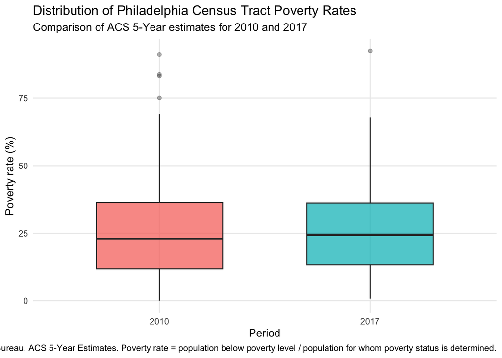

```r
poverty_long <- poverty_change |>
  select(
    GEOID,
    poverty_rt_2010,
    poverty_rt_2017
  ) |>
  pivot_longer(
    cols = c(poverty_rt_2010, poverty_rt_2017),
    names_to = "year",
    values_to = "poverty_rate"
  ) |>
  mutate(
    year = recode(
      year,
      poverty_rt_2010 = "2010",
      poverty_rt_2017 = "2017"
    ),
    poverty_rate = poverty_rate * 100
  )
figure_1 <- ggplot(
  poverty_long,
  aes(
    x = year,
    y = poverty_rate,
    fill = year
  )
) +
  geom_boxplot(
    alpha = 0.75,
    width = 0.6,
    outlier.alpha = 0.35
  ) +
  labs(
    title = "Distribution of Philadelphia Census Tract Poverty Rates",
    subtitle = "Comparison of ACS 5-Year estimates for 2010 and 2017",
    x = "Period",
    y = "Poverty rate (%)",
    fill = "Period",
    caption = paste(
      "Source: U.S. Census Bureau, ACS 5-Year Estimates.",
      "Poverty rate = population below poverty level /",
      "population for whom poverty status is determined."
    )
  ) +
  theme_minimal() +
  theme(
    legend.position = "none",
    panel.grid.minor = element_blank()
  )

figure_1
```

# FIGURE 2: Change in poverty rate with 90% margin of error

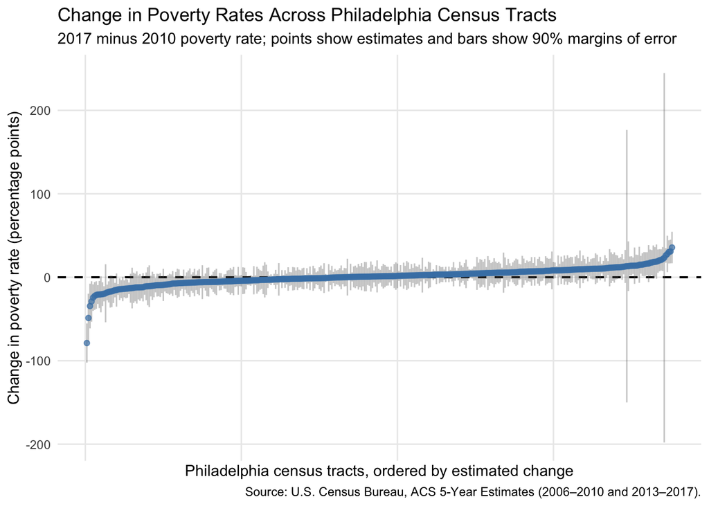

```r
error_bar_data <- poverty_change |>
  filter(
    !is.na(poverty_change),
    !is.na(change_moe)
  ) |>
  arrange(poverty_change) |>
  mutate(
    tract_order = row_number()
  )
figure_2 <- ggplot(
  error_bar_data,
  aes(
    x = tract_order,
    y = poverty_change * 100
  )
) +
  geom_hline(
    yintercept = 0,
    linetype = "dashed",
    color = "black",
    linewidth = 0.7
  ) +
  geom_errorbar(
    aes(
      ymin = (poverty_change - change_moe) * 100,
      ymax = (poverty_change + change_moe) * 100
    ),
    width = 0,
    alpha = 0.35,
    color = "gray40"
  ) +
  geom_point(
    size = 1.5,
    alpha = 0.7,
    color = "steelblue"
  ) +
  labs(
    title = "Change in Poverty Rates Across Philadelphia Census Tracts",
    subtitle = "2017 minus 2010 poverty rate; points show estimates and bars show 90% margins of error",
    x = "Philadelphia census tracts, ordered by estimated change",
    y = "Change in poverty rate (percentage points)",
    caption = "Source: U.S. Census Bureau, ACS 5-Year Estimates (2006–2010 and 2013–2017)."
  ) +
  theme_minimal() +
  theme(
    axis.text.x = element_blank(),
    axis.ticks.x = element_blank(),
    panel.grid.minor = element_blank()
  )

figure_2
```

**Is change statistically distinguishable from zero at 90% confidence?**

```r
poverty_change <- poverty_change |>
  mutate(
  lower = poverty_change - change_moe,
  upper = poverty_change + change_moe,
  significant_90 = lower > 0 | upper < 0
)
```

**How many tracts show a statistically detectable change and how many do not?**

```r
table(poverty_change$significant_90)
```

```
FALSE  TRUE
  313    63
```

FALSE: 313 There are 313 tracts without statistically detectable change.

TRUE: 63 There are 63 tracts with statistically detectable change.

**What tracts have missing values?**

```r
poverty_change |>
  filter(is.na(significant_90)) |>
  select(GEOID, NAME)
```

```
# A tibble: 8 × 2
  GEOID       NAME
  <chr>       <chr>
1 42101005000 Census Tract 50, Philadelphia County, Pennsylvania
2 42101980300 Census Tract 9803, Philadelphia County, Pennsylvania
3 42101980400 Census Tract 9804, Philadelphia County, Pennsylvania
4 42101980500 Census Tract 9805, Philadelphia County, Pennsylvania
5 42101980600 Census Tract 9806, Philadelphia County, Pennsylvania
6 42101980700 Census Tract 9807, Philadelphia County, Pennsylvania
7 42101980800 Census Tract 9808, Philadelphia County, Pennsylvania
8 42101980900 Census Tract 9809, Philadelphia County, Pennsylvania
```

These tracts have missing values: 50 : Philadelphia Navy Yard 9803 : NA 9804 : Philadelphia International Airport 9805 : NA 9806 : Stadiums / Commercial Area 9807 : Stadiums / Commercial Area 9808 : NA 9809 : Philadelphia International Airport

# Part 3 — Adjudicate

The analysis supports the article’s claim that that poverty rates changed in some Philadelphia census tracts between the 2006–2010 and 2013–2017 ACS periods.

That being said, this analysis cannot be used to determine a large majority of the claims in the article. This is for a variety of reasons but mainly being that the data only represents the poverty rate and does not indicate other factors such as the depth of poverty, the race associated with each tract, or the reason for which an individual may be in poverty. For this reason, claims such as 50% or more of people in poverty are living below the federal poverty rate, and a lack of employment, drug addiction, immigration or retirement are the main causes for increased poverty rates, cannot be supported.

Additionally, the article details poverty at the neighborhood scale whereas the census collects data by tracts, thus also making it difficult to draw sound data-based conclusions. Claims such as certain neighborhoods are becoming destinations for impoverished households to move into and poverty rates in majority-white neighborhoods are dramatically increasing cannot be fully determined since a single neighborhood is typically comprised of multiple tracts. Furthermore, census tracts do not fit neatly into a neighborhood boundary (which itself is up for dispute), but rather can cross and cut through neighborhoods in a variety of ways.

Finally, most of the claims in the article are anecdotal. Although they are presented alongside the census data and by seemingly reputable sources - food pantry directors, community organizers, social workers, etc. - this does not mean that the census data directly supports these claims.

In general, the ACS data supports evidence of change in some tracts, but not the causal explanations offered for why those changes occurred.

# Part 4 — Rewrite

**A new five-year federal survey shows that poverty rates changed in some Philadelphia neighborhoods between the 2006–2010 and 2013–2017 periods. In my analysis, 63 of 376 tracts had poverty-rate changes that were statistically distinguishable from zero at the 90 percent confidence level, while 313 did not. The data therefore shows that poverty shifted significantly in some parts of the city, but not all of it. It also does not establish why those changes occurred. The survey cannot determine whether changes resulted from the Great Recession, unemployment, migration, evictions, opioid addiction, retirement, or other factors suggested by residents and community leaders. Those explanations require additional evidence beyond the ACS poverty estimates. The five-year ACS also carries margins of error, making it important to distinguish measurable changes from differences that may reflect sampling uncertainty.**